# Count Models Tutorial

## Background Reading

I highly recommend Zuur et al, 2009, which walks through a number of types of ecological models with very readable examples and sometimes humor. The chapter on zero-inflated models uses hippos. If you would like an electronic copy, ask Rosie.

Zuur, A. F., E. N. Ieno, N. J. Walker, A. A. Saveliev, and G. M. Smith. 2009. Mixed Effects Models and Extensions in Ecology with R. Springer, New York, NY.

https://cran.r-project.org/web/packages/pscl/vignettes/countreg.pdf

Also: Perumean-Chaney, S. E., C. Morgan, D. McDowall, and I. Aban. 2013. Zero-inflated and overdispersed: what’s one to do? Journal of Statistical Computation and Simulation 83(9):1671-1683. doi:10.1080/00949655.2012.668550

and: Hu, M.-C., M. Pavlicova, and E. V. Nunes. 2011. Zero-inflated and hurdle models of count data with extra zeros: examples from an HIV-risk reduction intervention trial. The American journal of drug and alcohol abuse 37(5):367-375.

## Count data

As ecologists, we usually either measure things, or count things. When we measure things, they frequenly follow a more-or-less normal distribution (like the height of everyone in this room). However, when we count things (like the number of people collecting fish in the Delta every day) we end up with data that looks a lot different.

Count data differ from data with normal error in many ways, including

1. counts are discrete, and can be zero or positive integers only,
2. counts tend to bunch up on the small side of the range, creating a distribution with a positive skew,
3. a sample of counts can have an abundance of zeros, and
4. the variance of counts increases with the mean

Some count data can be approximated by a normal distribution and reasonably modeled with a linear model but more often, count data are modeled with Poisson distribution or negative binomial distribution using a generalized linear model (GLM). Poisson and negative binomial distributions are discrete probability distributions with two important properties:

1. the distribution contains only zero and positive integers and
2. the variance is a function of the mean.

```r
#non zero-inflated data

FMWT =  read_csv("2019.08.08_countmodels presentation/FMWT 1967-2021 Catch Matrix_updated_tidy.csv")
WYs = read_csv("2019.08.08_countmodels presentation/yearassignments.csv")
#add the water year type
FMWT = left_join(FMWT, WYs)
```

This is count data - number of fish. Usually, we expect count data to follow a Poisson distribution. Poisson – A Poisson distribution is the probability distribution of the number of occurrences of some thing (in this case fish) generated by a process that generates the thing at a constant rate per unit effort (duration or space). This constant rate is λ, which is the expectation, so E(Y)= μ = λ. Because the rate per effort is constant, the variance of a Poisson variable equals the mean.

If we try to model catch of fish per trawl, we are going to get too many zeros (which is the second part of this lesson), so we are going to summarize the data and model total catch of Striped Bass per month.

```r
SB = filter(FMWT, Species %in% c("Striped Bass age-0", "Striped Bass age-1",
                                 "Striped Bass age-1", "Striped Bass age-2")) %>%
              group_by(Year, SampleDate, SurveyNumber, StationCode, Volume, Yr_type) %>%
              summarize(Catch = sum(Catch, na.rm = T))
```

[output not shown]

```r
SBtot = group_by(SB, Year, SurveyNumber, Yr_type) %>%
  summarize(samples = n(), Volume = sum(Volume, na.rm = T), Catch = sum(Catch, na.rm = T))
```

The first thing I like doing with a data set is plotting it in various ways to “get to know it”.

We are interested in changes over time, and changes with water year type, so lets start by graphing it that way.

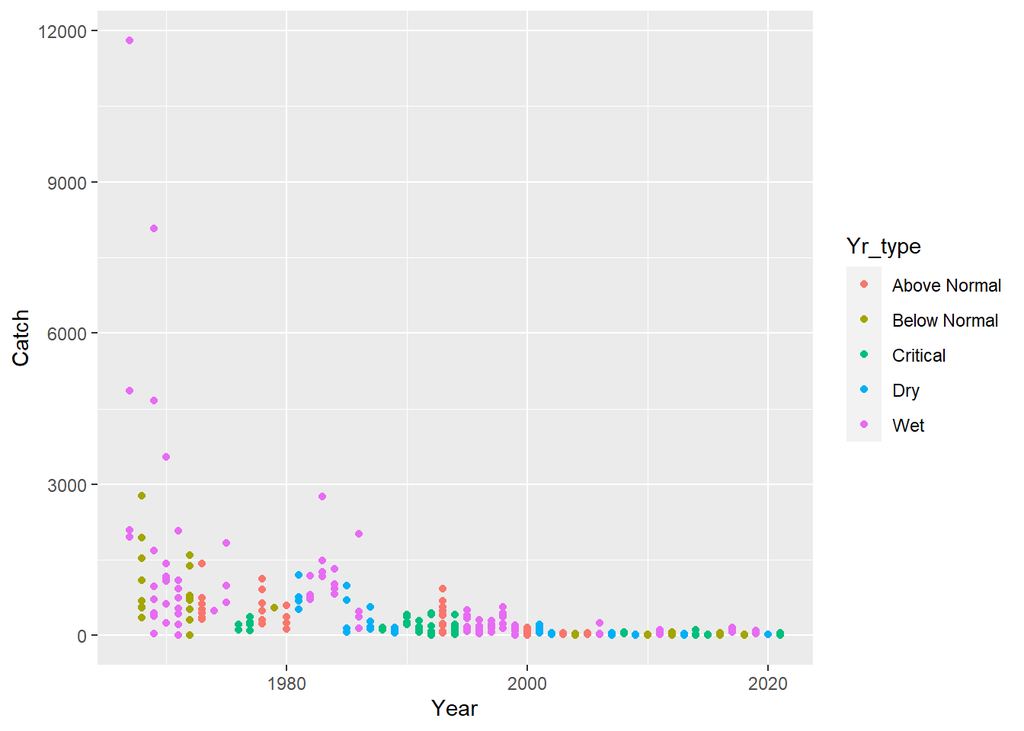

```r
ggplot(SBtot, aes(x = Year, y = Catch, color = Yr_type))+ geom_point()
```

OK, we see there were a lot higher catches earlier in the time series, maybe higher catches in wet years, but it’s hard to tell.

Before we run a model, let’s look at a histogram of the data to see if it’s more or less normally distributed. Since it’s count data, it’s not likely to be, but you never know.

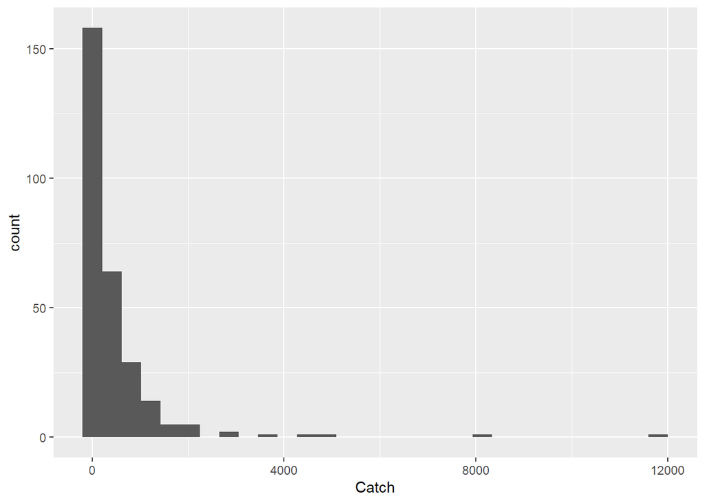

```r
ggplot(SBtot, aes(x = Catch)) + geom_histogram()
```

Um, no.

Can we log-transform it to make it normally distributed?

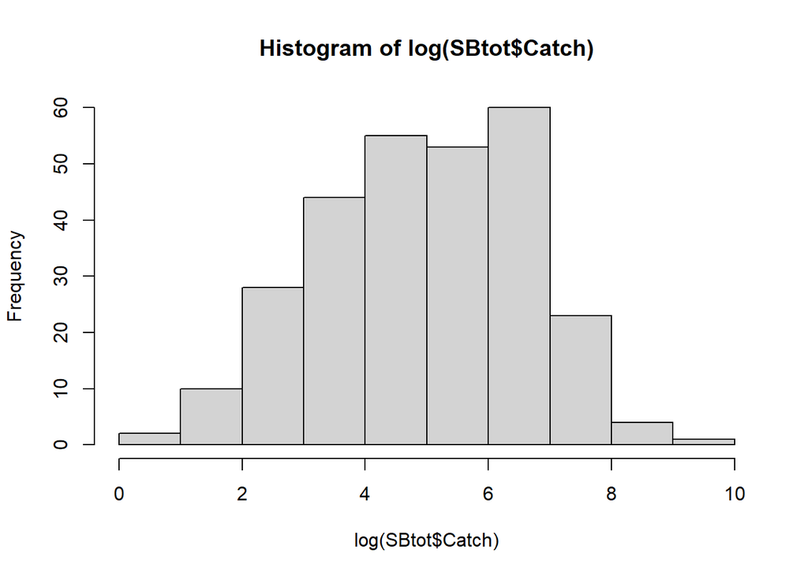

```r
hist(log(SBtot$Catch))
```

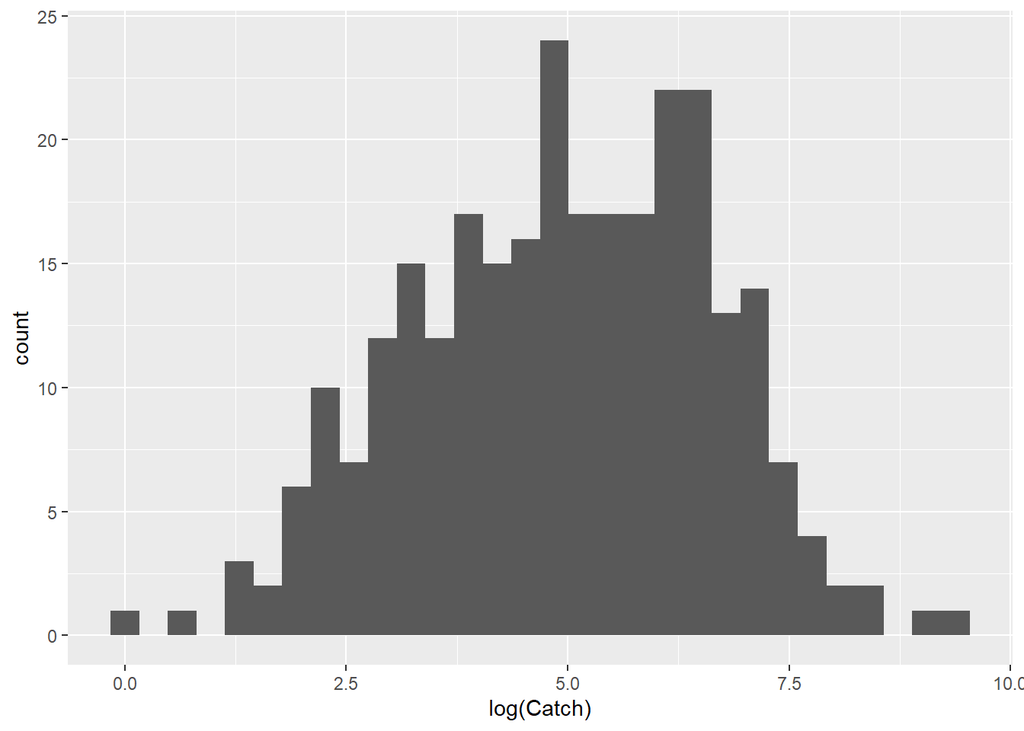

```r
ggplot(SBtot, aes(x = log(Catch))) + geom_histogram()
```

OK, log transforming gives us a pretty nice bell curve. Now we have two options:

1. Do a regular old linear model on the log-transformed data.
2. Do a generalized linear model on the raw data with a better distribution.

Let’s start with a log-transformed model

```r
sblm = lm(log(Catch+1)~  Year + Yr_type, data = SBtot)
summary(sblm)
```

```
##
## Call:
## lm(formula = log(Catch + 1) ~ Year + Yr_type, data = SBtot)
##
## Residuals:
##     Min      1Q  Median      3Q     Max
## -5.4694 -0.5823  0.0345  0.7027  1.9899
##
## Coefficients:
##                       Estimate Std. Error t value Pr(>|t|)
## (Intercept)         158.099546   8.386281  18.852   <2e-16 ***
## Year                 -0.076865   0.004214 -18.239   <2e-16 ***
## Yr_typeBelow Normal  -0.384497   0.235413  -1.633   0.1035
## Yr_typeCritical      -0.239266   0.216227  -1.107   0.2695
## Yr_typeDry           -0.367257   0.227550  -1.614   0.1077
## Yr_typeWet            0.479851   0.193401   2.481   0.0137 *
## ---
## Signif. codes:  0 '***' 0.001 '**' 0.01 '*' 0.05 '.' 0.1 ' ' 1
##
## Residual standard error: 1.05 on 276 degrees of freedom
## Multiple R-squared:  0.6177, Adjusted R-squared:  0.6108
## F-statistic: 89.18 on 5 and 276 DF,  p-value: < 2.2e-16
```

Well! It’s significant! So that’s good. but let’s check our diagnostic plots

If you need a review of what these plots mean: https://data.library.virginia.edu/diagnostic-plots/

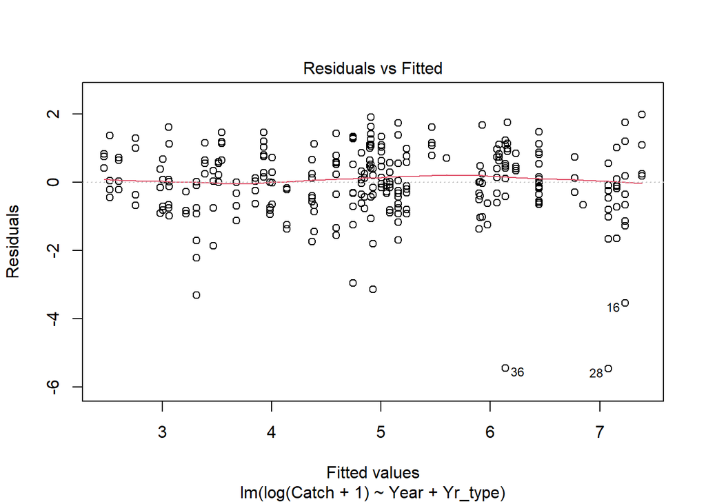

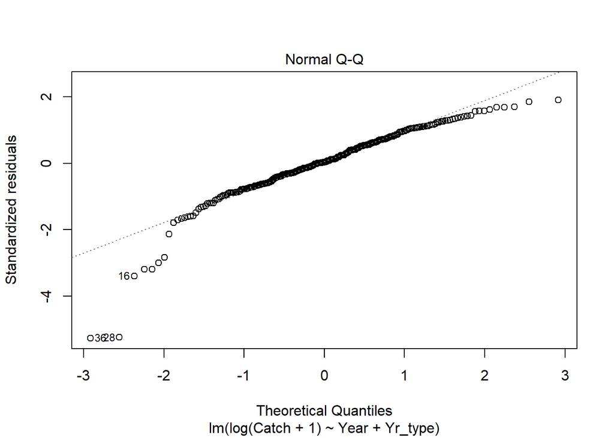

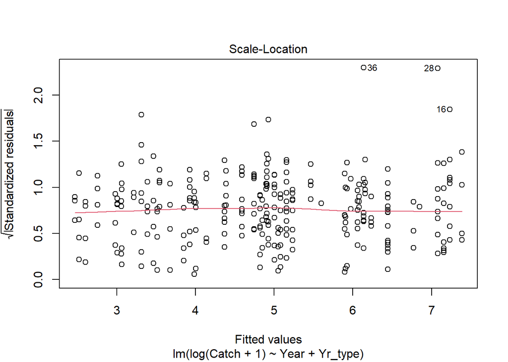

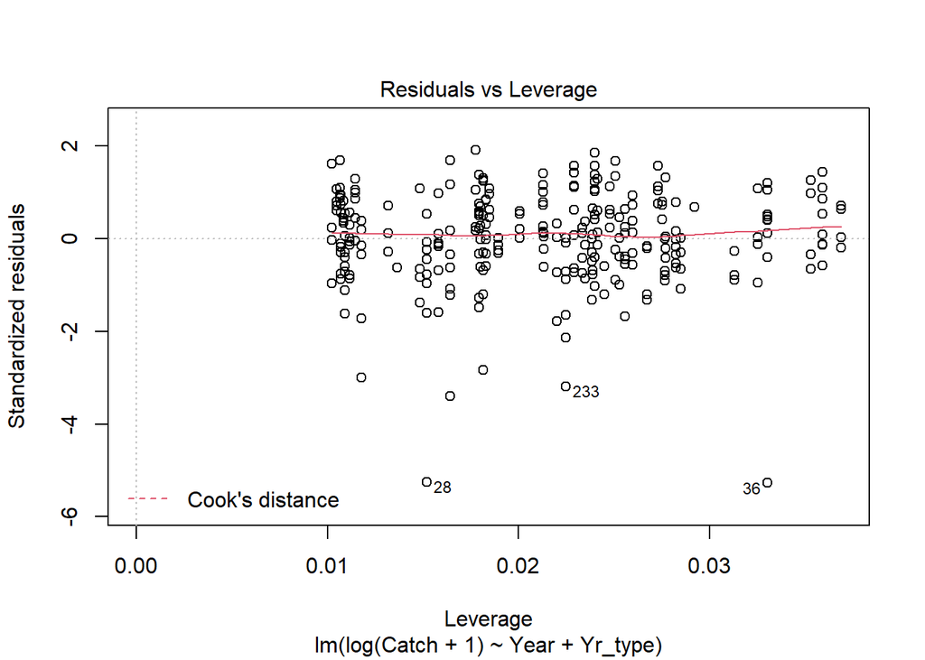

```r
plot(sblm)
```

The tails of the normal QQ plot don’t look great, but otherwise it isn’t terrible.

However, there are issues with transforming data. It works, and it allows you to use statistical tests that you learned in Stats 101, but tends to have greater error rates and poor predictive capabilities.

For an overview of the issues, I recommend this blog post and the article it was based on

https://www.r-bloggers.com/do-not-log-transform-count-data-bitches/

O’Hara, R. B., and D. J. Kotze. 2010. Do not log-transform count data. Methods in Ecology and Evolution 1(2):118-122. doi:https://doi.org/10.1111/j.2041-210X.2010.00021.x

Furthermore, using of transformed data or non-parametric hypothesis tests are are really justtools for computing “correct” p -values. They don’t give you parameter extimates that are very meaningful, making them hard to interpret.

Since I mentioned predictions, let’s see how many Striped Bass we will catch 50 years from now

```r
#Make a new data frame with the years we want to use
newdata = data.frame(Year = c(2055, 2065, 2075), Yr_type = c("Dry", "Dry", "Dry"))

#Use the "predict" fundtion to see what we get
predict(sblm, newdata = newdata)
```

```
##          1          2          3
## -0.2248838 -0.9935319 -1.7621799
```

```r
#since we log-transformed the data we will want to back-transform them to put them in the original scale.
exp(predict(sblm, newdata = newdata))
```

```
##         1         2         3
## 0.7986090 0.3702666 0.1716702
```

## Generalized Linear Models for Count Data

If you remember your introductory statistics classes, they probably said that count data are usually best described using a poisson distribution.

https://en.wikipedia.org/wiki/Poisson_distribution

While normal distributions are described by two parameters (mean and variance), Poisosn distributions are described by a single parameter (lambda) which is both the mean and variance, because in a Poisson distribution the mean is always equal to the variance.

If our striped bass data followed a poisson distribution, we would expect the (geometric) mean of the data to be equal to the variance.

```r
#Geometric mean of striped bass data

(meanSB = exp(mean(log(SBtot$Catch+1))))
```

```
## [1] 138.4671
```

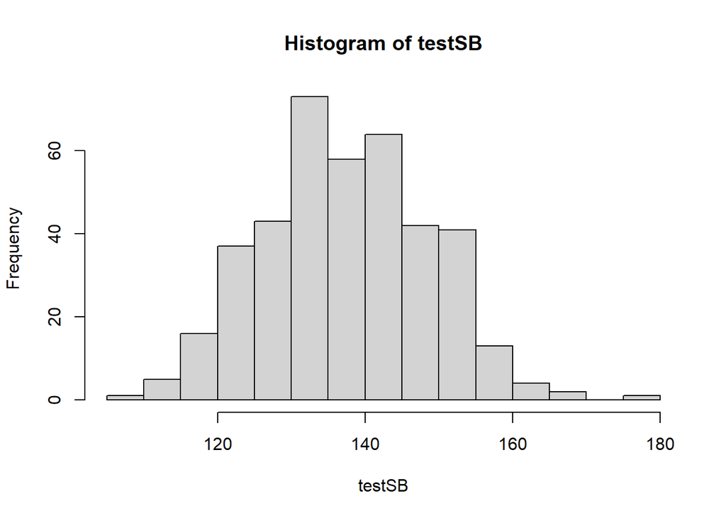

```r
testSB = rpois(400, lambda = meanSB)
hist(testSB)
```

```r
#variance
var(SBtot$Catch)
```

```
## [1] 1070614
```

```r
mean(SBtot$Catch)
```

```
## [1] 462.305
```

So, we see that the variance is way higher than the mean.

We could also do a dispersion test, which relies on the fact that the Poisson distribution’s mean is equal to its variance, and the the ratio of the variance to the mean in a sample of n counts from a Poisson distribution should follow a Chi-square distribution with n-1 degrees of freedom.

```r
dispersion_test <- function(x)
{
  res <- 1-2 * abs((1 - pchisq((sum((x - mean(x))^2)/mean(x)), length(x) - 1))-0.5)

  cat("Dispersion test of count data:\n",
      length(x), " data points.\n",
      "Mean: ",mean(x),"\n",
      "Variance: ",var(x),"\n",
      "Probability of being drawn from Poisson distribution: ",
      round(res, 3),"\n", sep = "")

  invisible(res)
}

dispersion_test(SBtot$Catch)
```

```
## Dispersion test of count data:
## 282 data points.
## Mean: 462.305
## Variance: 1070614
## Probability of being drawn from Poisson distribution: 0
```

So no. It is way over-dispersed. But just for fun, let’s look at what a linear model would look like.

```r
lm2 = glm(Catch ~ Year + Yr_type, data = SBtot, family = "poisson")
summary(lm2)
```

```
##
## Call:
## glm(formula = Catch ~ Year + Yr_type, family = "poisson", data = SBtot)
##
## Deviance Residuals:
##     Min       1Q   Median       3Q      Max
## -62.097   -9.996   -3.715    4.132  134.897
##
## Coefficients:
##                       Estimate Std. Error  z value Pr(>|z|)
## (Intercept)         159.275177   0.562447  283.182   <2e-16 ***
## Year                 -0.077318   0.000284 -272.260   <2e-16 ***
## Yr_typeBelow Normal  -0.115044   0.011565   -9.947   <2e-16 ***
## Yr_typeCritical      -0.363757   0.014070  -25.854   <2e-16 ***
## Yr_typeDry            0.117776   0.014241    8.270   <2e-16 ***
## Yr_typeWet            0.625281   0.009176   68.145   <2e-16 ***
## ---
## Signif. codes:  0 '***' 0.001 '**' 0.01 '*' 0.05 '.' 0.1 ' ' 1
##
## (Dispersion parameter for poisson family taken to be 1)
##
##     Null deviance: 267802  on 281  degrees of freedom
## Residual deviance:  98432  on 276  degrees of freedom
## AIC: 100343
##
## Number of Fisher Scoring iterations: 5
```

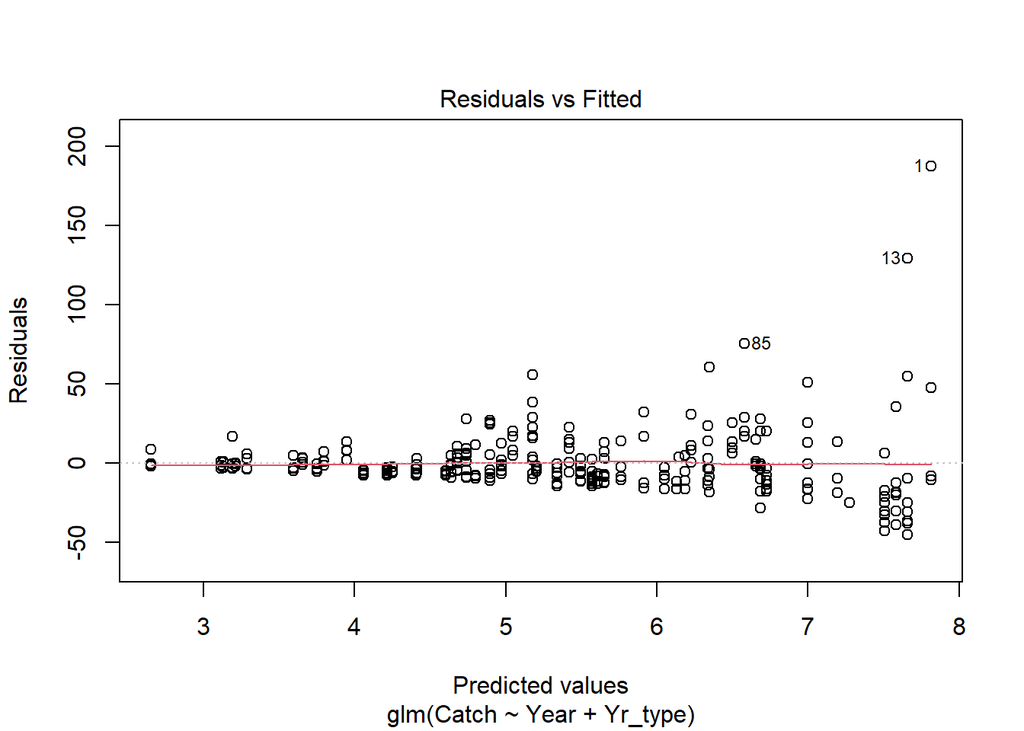

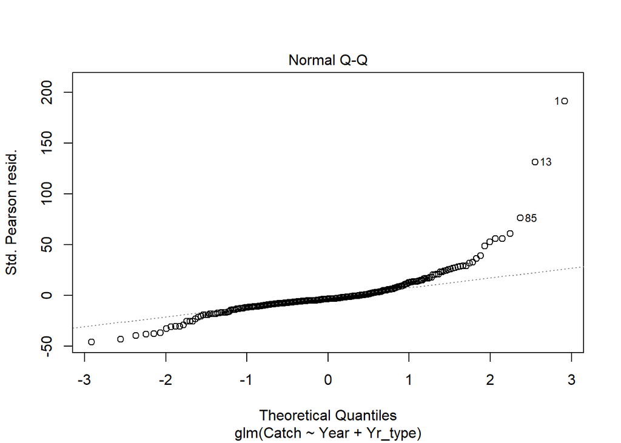

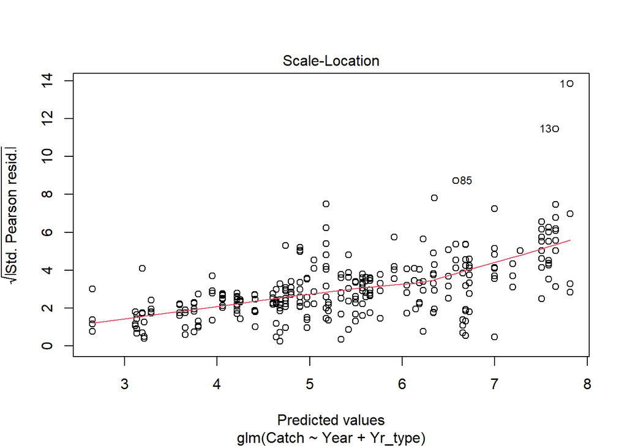

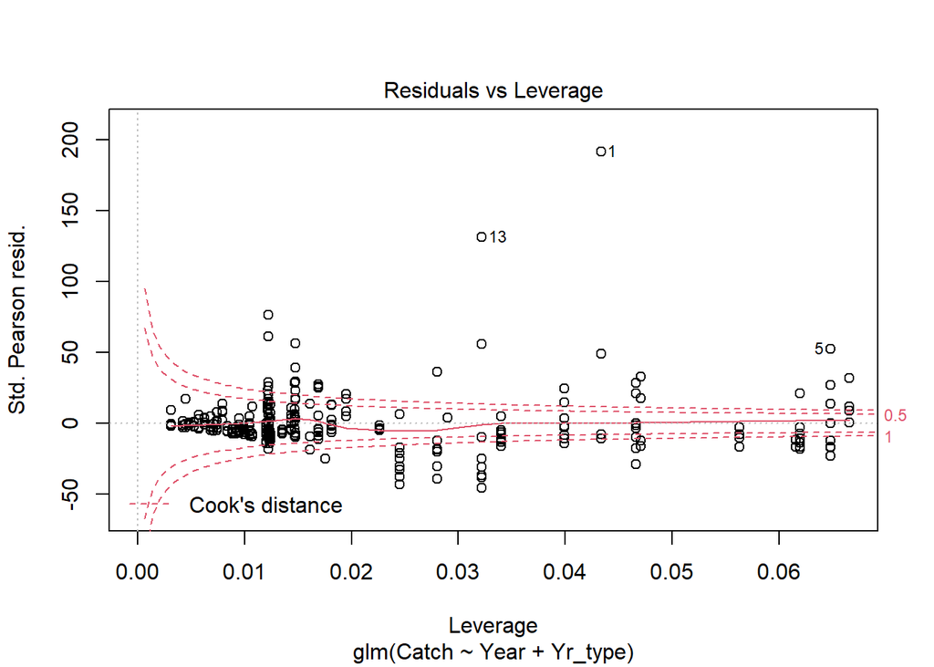

```r
plot(lm2)
```

We can use the DHARMa package to simulate residuals and create slightly different diagnostic plots, as well as check for overdispersison.

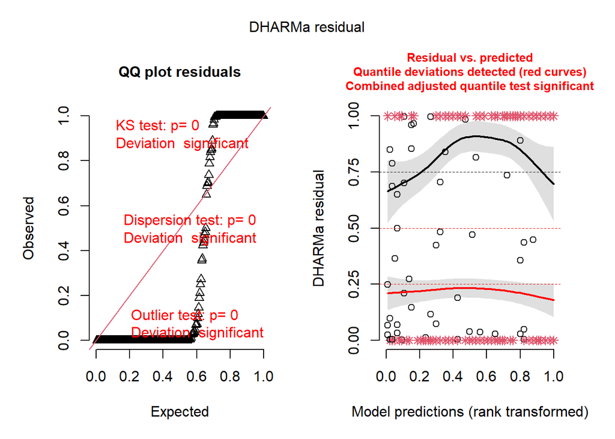

```r
simOut <- simulateResiduals(fittedModel = lm2, n_sim = 200)
  plot(simOut, asFactor = F)
```

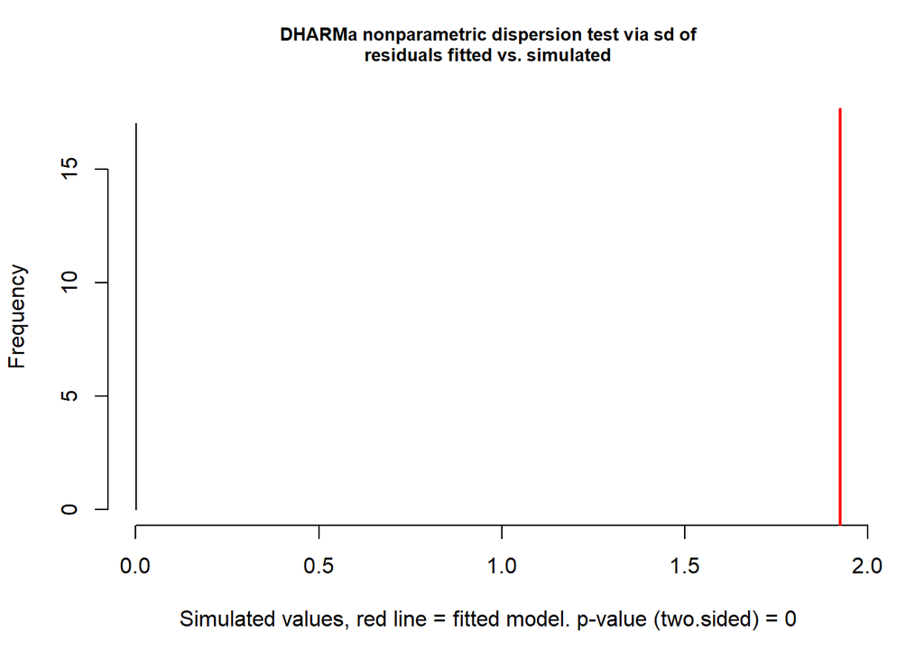

```
##
##  DHARMa nonparametric dispersion test via sd of residuals fitted vs.
##  simulated
##
## data:  simulationOutput
## dispersion = 1506.4, p-value < 2.2e-16
## alternative hypothesis: two.sided
```

```r
  testDispersion(simOut)
```

You can see that the residuals versus fitted values plot has variance that increases as predicted values increase (that’s bad) and now the right tail of the normal QQ plot looks bad. Plus, there are lot of points outside teh cooks distance, which means they are outliers. And it’s WAY overdisspersed. This fits worse than than the log-transformed version!

So what now? We have two choices quasipoisson and negative binomial.

## Quasipoisson

Quasipoisson’s are kinda weird, so check out this explanation from Zuur et al. 2009: A quassipoisson model uses the mean regression function and variance from the Poisson regression, but leaves the dispersion parameter unrestricted. (in a Poisson model dispersion = 1). Do not write in your report or paper that you used a quasi-Poisson distribution. Just say that you did a Poisson GLM, detected overdispersion, and corrected the standard errors using a quasi-GLM model where the variance is given by φ × μ, where μ is the mean and φ the dispersion parameter.

```r
sb = glm(Catch~  Year, family = quasipoisson, data = SBtot)
print("dispersion coefficient")
```

```
## [1] "dispersion coefficient"
```

```r
summary(sb)$dispersion
```

```
## [1] 575.7554
```

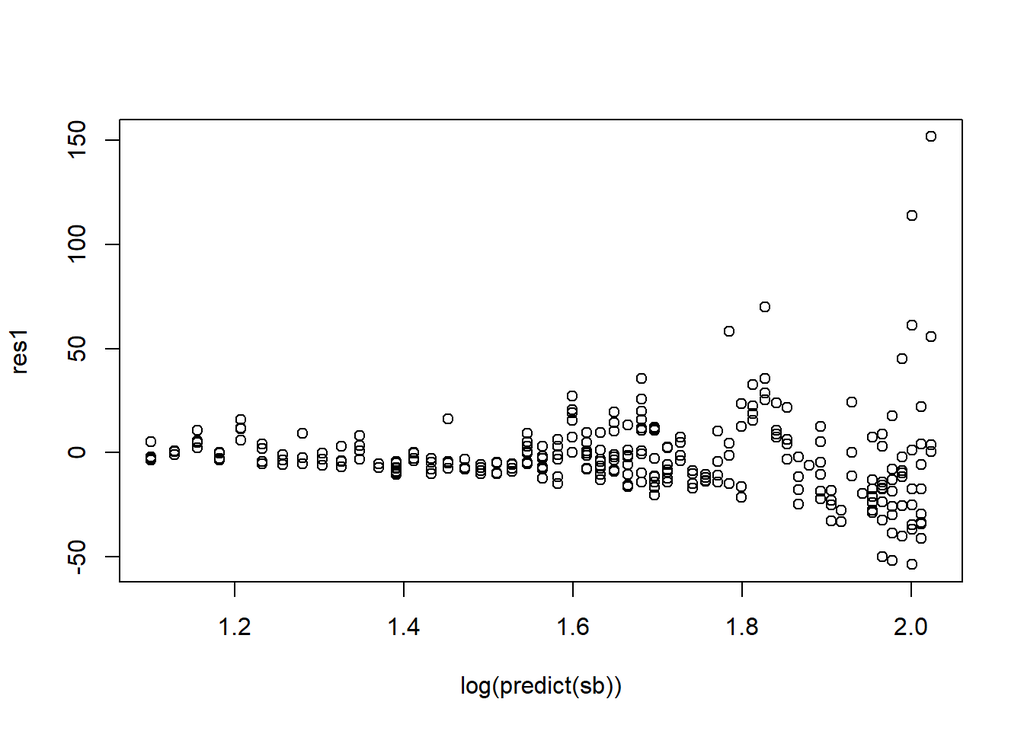

```r
#test our residuals and QQ plot
res1 <- residuals(sb, type="deviance")
plot(log(predict(sb)), res1)
```

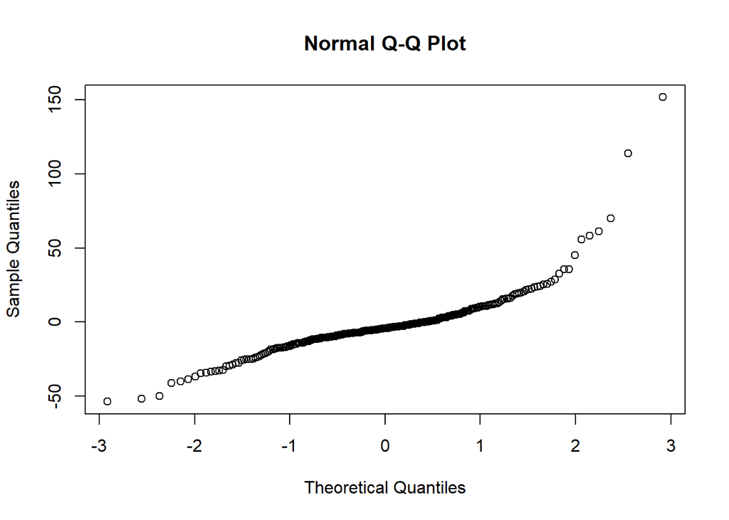

```r
qqnorm(res1)
```

```r
#test for differences between the two model specifications
print("p-value")
```

```
## [1] "p-value"
```

```r
pchisq(summary(sb)$dispersion * lm2$df.residual, lm2$df.residual, lower = F)
```

```
## [1] 0
```

```r
#it's very overdisperssed
```

So this looks better than the regular Poisson, but the right hand of the QQ plot is still a little off, and the Residuals versus Fitten plot isn’t great either.

### Negative Binomial

We can try and see if a negative binomial model fits better than a quasipoisson. Negative binomial distributions account for overdisperssion, but variance is a quadratic function of the mean rather than a linear function of the mean (as in quasipoisson). There is lots of discussion as to which is better (e.g. Ver Hoef and Bveng 2007).

```r
sbnb = glm.nb(Catch~  Year + Yr_type,  data = SBtot)
summary(sbnb)
```

```
##
## Call:
## glm.nb(formula = Catch ~ Year + Yr_type, data = SBtot, init.theta = 1.37649237,
##     link = log)
##
## Deviance Residuals:
##     Min       1Q   Median       3Q      Max
## -3.7350  -0.9794  -0.3891   0.3870   2.4852
##
## Coefficients:
##                       Estimate Std. Error z value Pr(>|z|)
## (Intercept)         166.092487   6.883384  24.129  < 2e-16 ***
## Year                 -0.080704   0.003459 -23.330  < 2e-16 ***
## Yr_typeBelow Normal  -0.386085   0.192751  -2.003 0.045175 *
## Yr_typeCritical      -0.245238   0.176595  -1.389 0.164922
## Yr_typeDry           -0.252288   0.186072  -1.356 0.175142
## Yr_typeWet            0.554561   0.157561   3.520 0.000432 ***
## ---
## Signif. codes:  0 '***' 0.001 '**' 0.01 '*' 0.05 '.' 0.1 ' ' 1
##
## (Dispersion parameter for Negative Binomial(1.3765) family taken to be 1)
##
##     Null deviance: 946.98  on 281  degrees of freedom
## Residual deviance: 315.92  on 276  degrees of freedom
## AIC: 3564.8
##
## Number of Fisher Scoring iterations: 1
##
##
##               Theta:  1.376
##           Std. Err.:  0.108
##
##  2 x log-likelihood:  -3550.764
```

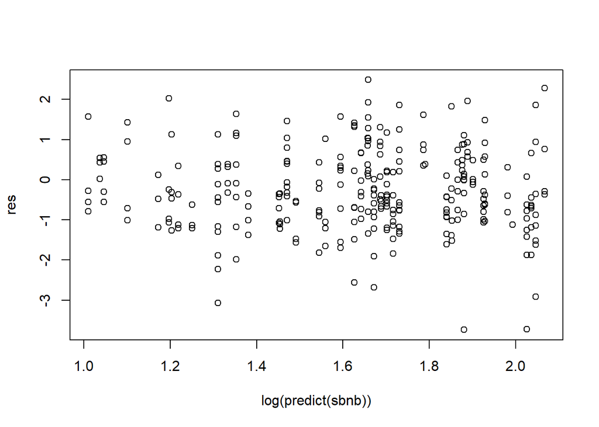

```r
#For reasons I do not understand, the 'plot' function doesn't do the QQ plot right
#with negative binomial distributions, so I do it by hand:
res <- residuals(sbnb, type="deviance")
plot(log(predict(sbnb)), res)
```

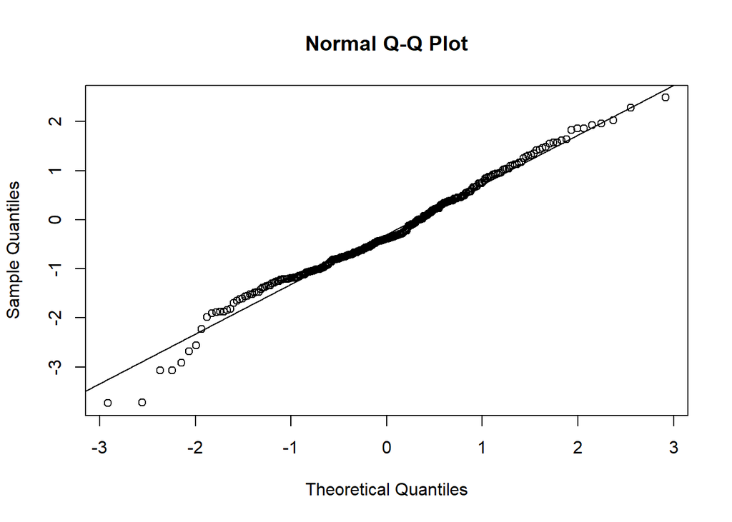

```r
qqnorm(res)
qqline(res)
```

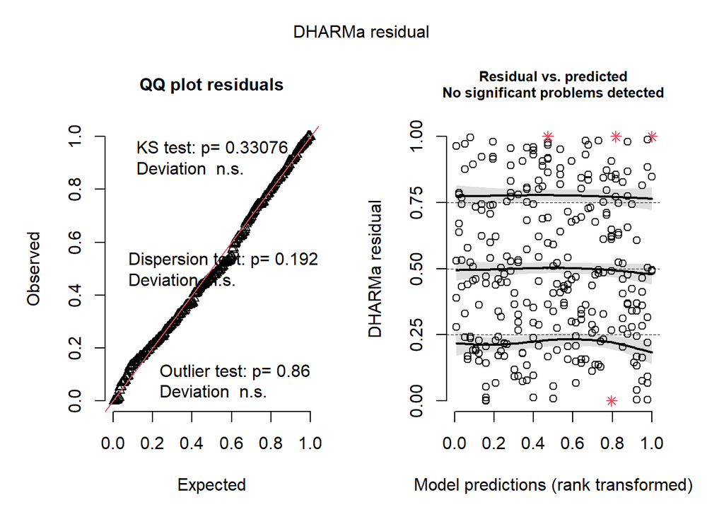

```r
#we can also use the DHARMa package
simOut <- simulateResiduals(fittedModel = sbnb, n_sim = 200)
  plot(simOut, asFactor = F)
```

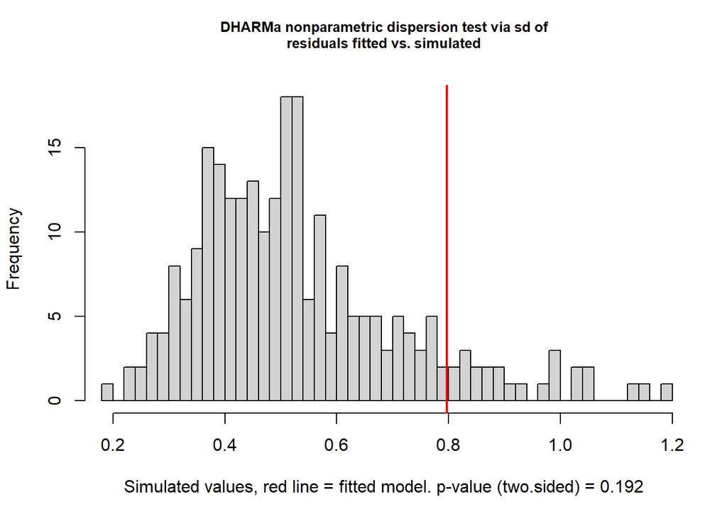

```
##
##  DHARMa nonparametric dispersion test via sd of residuals fitted vs.
##  simulated
##
## data:  simulationOutput
## dispersion = 1.5017, p-value = 0.192
## alternative hypothesis: two.sided
```

```r
  testDispersion(simOut)
```

Those look pretty good! I love how the plot says “No significant problems detected”.

However, if we want to use this model for anything we need to make sure we understand the output.

```r
summary(sbnb)
```

```
##
## Call:
## glm.nb(formula = Catch ~ Year + Yr_type, data = SBtot, init.theta = 1.37649237,
##     link = log)
##
## Deviance Residuals:
##     Min       1Q   Median       3Q      Max
## -3.7350  -0.9794  -0.3891   0.3870   2.4852
##
## Coefficients:
##                       Estimate Std. Error z value Pr(>|z|)
## (Intercept)         166.092487   6.883384  24.129  < 2e-16 ***
## Year                 -0.080704   0.003459 -23.330  < 2e-16 ***
## Yr_typeBelow Normal  -0.386085   0.192751  -2.003 0.045175 *
## Yr_typeCritical      -0.245238   0.176595  -1.389 0.164922
## Yr_typeDry           -0.252288   0.186072  -1.356 0.175142
## Yr_typeWet            0.554561   0.157561   3.520 0.000432 ***
## ---
## Signif. codes:  0 '***' 0.001 '**' 0.01 '*' 0.05 '.' 0.1 ' ' 1
##
## (Dispersion parameter for Negative Binomial(1.3765) family taken to be 1)
##
##     Null deviance: 946.98  on 281  degrees of freedom
## Residual deviance: 315.92  on 276  degrees of freedom
## AIC: 3564.8
##
## Number of Fisher Scoring iterations: 1
##
##
##               Theta:  1.376
##           Std. Err.:  0.108
##
##  2 x log-likelihood:  -3550.764
```

This shows us the coefficients on the log scale (remember we are using a log link), and the factor coefficients show us the difference between the intercept and each factor level, but we also probably want to know the differences between each pair of factors. We can use the `emmeans` function for that.

The modeled means on the link scale (log) are:

```r
emm = emmeans(sbnb, specs = "Yr_type")

emm
```

```
##  Yr_type      emmean     SE  df asymp.LCL asymp.UCL
##  Above Normal   5.27 0.1325 Inf      5.01      5.52
##  Below Normal   4.88 0.1402 Inf      4.60      5.15
##  Critical       5.02 0.1156 Inf      4.79      5.25
##  Dry            5.01 0.1284 Inf      4.76      5.26
##  Wet            5.82 0.0871 Inf      5.65      5.99
##
## Results are given on the log (not the response) scale.
## Confidence level used: 0.95
```

For the response scale it is:

```r
emm2 = emmeans(sbnb, specs = "Yr_type", type = "response")

emm2
```

```
##  Yr_type      response   SE  df asymp.LCL asymp.UCL
##  Above Normal      193 25.6 Inf     149.2       251
##  Below Normal      132 18.4 Inf      99.9       173
##  Critical          151 17.5 Inf     120.7       190
##  Dry               150 19.3 Inf     116.9       193
##  Wet               337 29.3 Inf     284.0       400
##
## Confidence level used: 0.95
## Intervals are back-transformed from the log scale
```

If we want the pairwise comparisons between year types

```r
summary(contrast(emm2, method="pairwise", adjust="none", type="response"), infer=c(TRUE, TRUE))
```

```
##  contrast                    ratio     SE  df asymp.LCL asymp.UCL null z.ratio
##  Above Normal / Below Normal 1.471 0.2836 Inf     1.008     2.147    1   2.003
##  Above Normal / Critical     1.278 0.2257 Inf     0.904     1.806    1   1.389
##  Above Normal / Dry          1.287 0.2395 Inf     0.894     1.853    1   1.356
##  Above Normal / Wet          0.574 0.0905 Inf     0.422     0.782    1  -3.520
##  Below Normal / Critical     0.869 0.1580 Inf     0.608     1.241    1  -0.774
##  Below Normal / Dry          0.875 0.1667 Inf     0.602     1.271    1  -0.702
##  Below Normal / Wet          0.390 0.0643 Inf     0.283     0.539    1  -5.708
##  Critical / Dry              1.007 0.1723 Inf     0.720     1.408    1   0.041
##  Critical / Wet              0.449 0.0655 Inf     0.338     0.598    1  -5.485
##  Dry / Wet                   0.446 0.0702 Inf     0.328     0.608    1  -5.126
##  p.value
##   0.0452
##   0.1649
##   0.1751
##   0.0004
##   0.4388
##   0.4826
##   <.0001
##   0.9671
##   <.0001
##   <.0001
##
## Confidence level used: 0.95
## Intervals are back-transformed from the log scale
## Tests are performed on the log scale
```

The emmeans package reports the name of the term as the ratio of the coefficient term to the intercept term (the reference treatment level). Remember that a coefficient is a difference in conditional means, which gives us the relative effect of the one factor level versus another. Remember that effects on the response scale are not additive, but multiplicative!

Let’s look at this visually, first on the link scale:

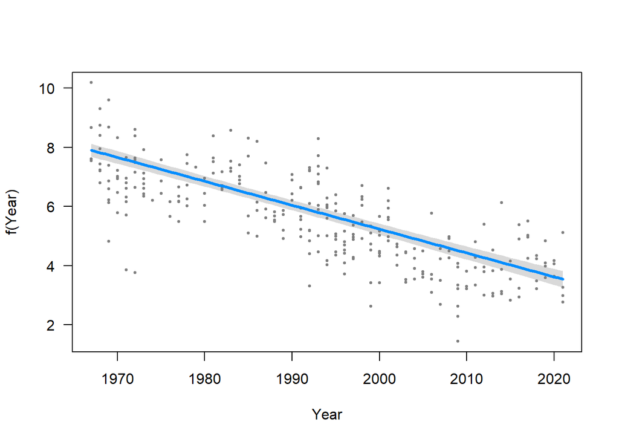

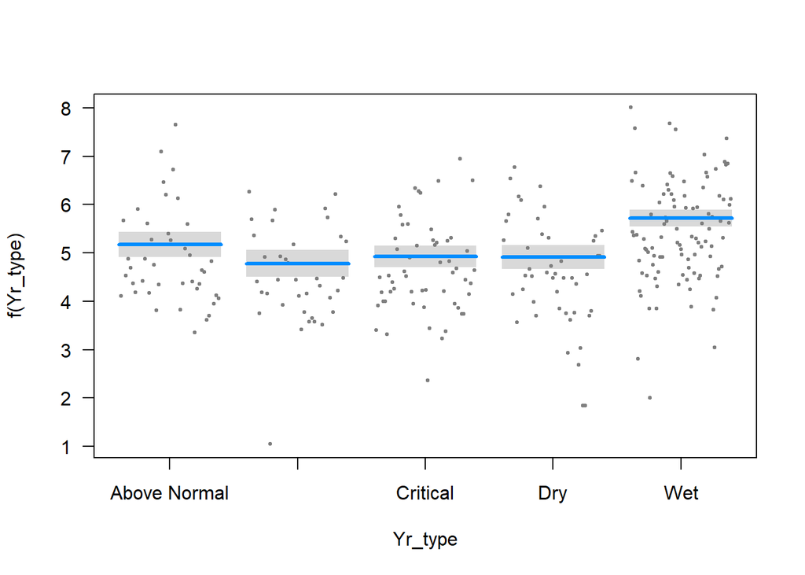

```r
library(visreg)
visreg(sbnb)
```

Now on the response scale:

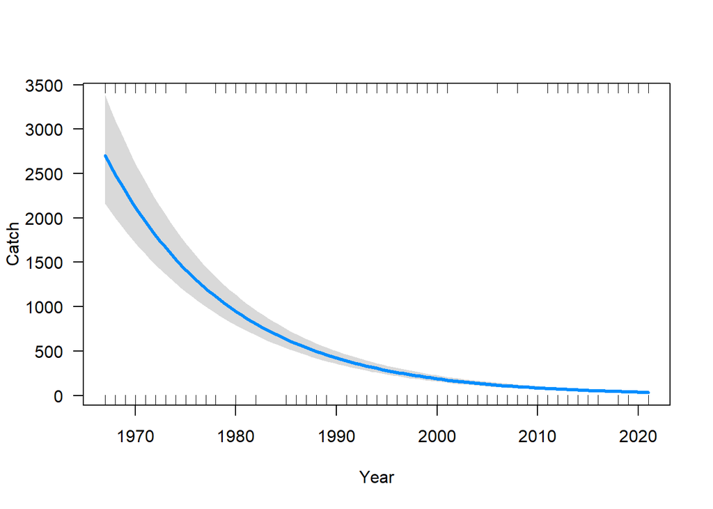

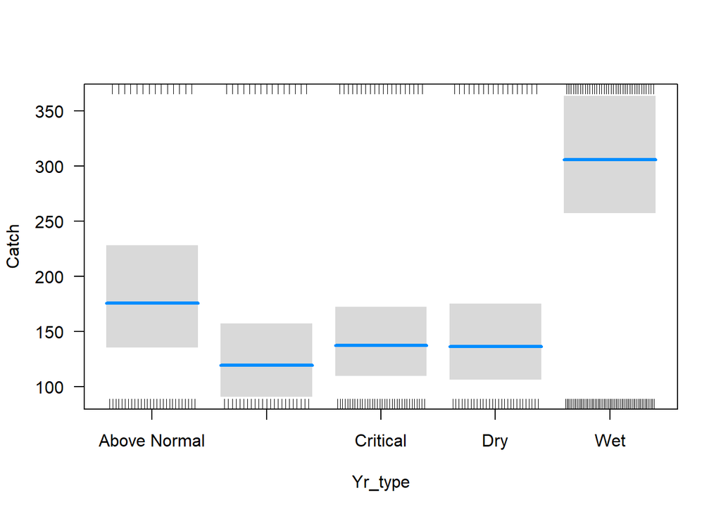

```r
visreg(sbnb, scale = "response")
```

## Offests

So, you’ll notice that we modeled the counts of fish. However, it is much more common to want to know differences in catch per unit effort. With FMWT, the effort for each tow is pretty close, so it’s not a huge deal, but in other situations including effort is pretty important. Let’s try running a negative binomial model on CPUE!

```r
SBtot$CPUE = SBtot$Catch/SBtot$Volume*10000
SBtot2 = dplyr::filter(SBtot, !is.na(Volume), Volume != 0)

sbnb2 = glm.nb(CPUE ~  Year,  data = SBtot2)
#NOPE
```

Negative binomial models assume you have count data. If your data are not integers, you have two options:

1. Round the data so they become integers. You shouldn’t do this. It’s wrong. Sometimes I do it in exploritory analyses if I only have CPUE data without the raw count data, but you should contact the data provider and get the raw count and effort data later.
2. Use an offset. In this case, we take the log of volume (since there’s log-link).

```r
sbnb3 = glm.nb(Catch ~ Year +offset(log(SBtot2$Volume)), data = SBtot2)
summary(sbnb3)
```

```
##
## Call:
## glm.nb(formula = Catch ~ Year + offset(log(SBtot2$Volume)), data = SBtot2,
##     init.theta = 1.415163573, link = log)
##
## Deviance Residuals:
##     Min       1Q   Median       3Q      Max
## -2.4290  -1.0301  -0.4741   0.3390   2.5733
##
## Coefficients:
##               Estimate Std. Error z value Pr(>|z|)
## (Intercept) 154.021937  12.294605   12.53   <2e-16 ***
## Year         -0.081289   0.006143  -13.23   <2e-16 ***
## ---
## Signif. codes:  0 '***' 0.001 '**' 0.01 '*' 0.05 '.' 0.1 ' ' 1
##
## (Dispersion parameter for Negative Binomial(1.4152) family taken to be 1)
##
##     Null deviance: 375.80  on 191  degrees of freedom
## Residual deviance: 212.99  on 190  degrees of freedom
## AIC: 2133.9
##
## Number of Fisher Scoring iterations: 1
##
##
##               Theta:  1.415
##           Std. Err.:  0.136
##
##  2 x log-likelihood:  -2127.850
```

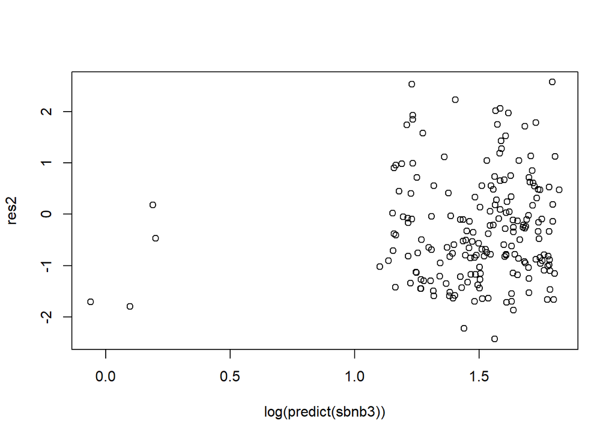

```r
res2 <- residuals(sbnb3, type="deviance")
plot(log(predict(sbnb3)), res2)
```

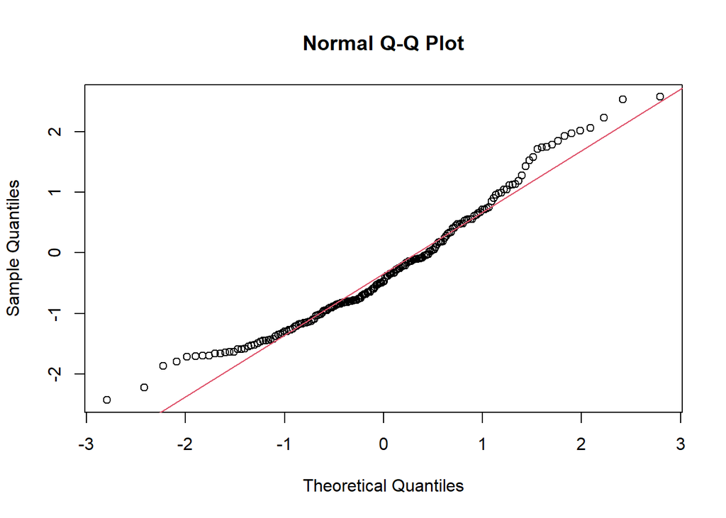

```r
qqnorm(res2)
qqline(res2, col = 2)
```

## Zero-inflated model example

OK, that was striped bass. Striped bass are easy because we catch a lot of them. Also, I purposely used summaries by survey since we almost never have an entire month of FMWT (140 stations) with zero bass catch. However, frequently when we deal with count data we have more zeros than we should. This is (appropriately) known as zero-inflation.

```r
FMWT_DS = dplyr::filter(FMWT, Species == "Delta Smelt")


#just look at data from 1990-2020
FMWT_DS2 = dplyr::filter(FMWT_DS, Year <= 2020, Year > 1990, StationCode %in% c(605, 606, 608)) %>%
  mutate(Cond = scale(ConductivityTop), Sec = scale(Secchi), Year2 = scale(Year),
         Temp = scale(WaterTemperature))
```

## Get to know your data

I want to use this dataset to investigate what environmental parameters affect Delta Smelt catch. I might be able to use similar tools as for the Striped Bass data, but I might not. As with the Sriped Bass data, the first step in any analysis is making sure you understand your data and do a few basic exploritory plots.

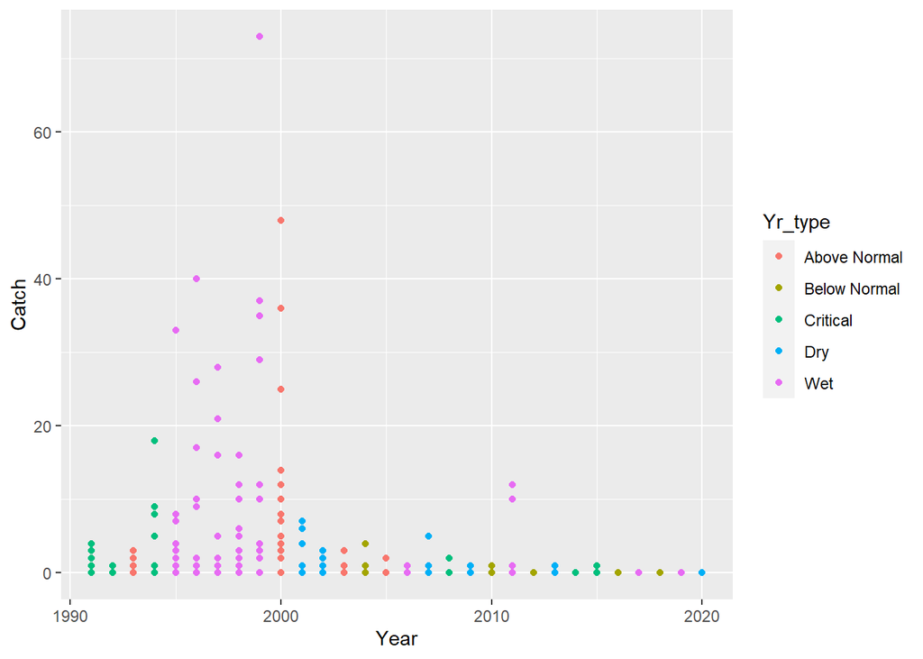

```r
ggplot(FMWT_DS2, aes(x = Year, y = Catch, color = Yr_type)) +geom_point()
```

Well, that’s pretty.

Now let’s look at the distribution. Histogram time! Maybe we’ll get lucky and we will get a nice bell curve right off the bat.

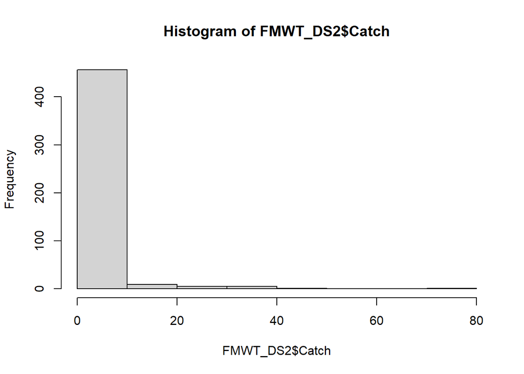

```r
hist(FMWT_DS2$Catch)
```

That’s definitely not normal. It might be Poisson, but there are a LOT of zeros.